# ANOVA

Homework Quiz

Author

Nathan Lunceford

# Life Expectancy of Female Authors

## Introduction

You are curious to compare life expectancy between female poets, novelists, and non-fiction writers.

You take a sample of female authors from each of the three groups to test if the average age at death is different between any of the three types of authors using a level of significance of, $\alpha = 0.05$.

## Load the Data and Libraries

```r
library(rio)
library(tidyverse)
library(mosaic)
library(car)

womenpoet <- rio::import("https://byuistats.github.io/BYUI_M221_Book/Data/womenpoet.xls")
```

## Explore the Data

Create a side-by-side boxplot of the age at death of each of the different author styles.

Modify the colors of each of the boxes for each group.

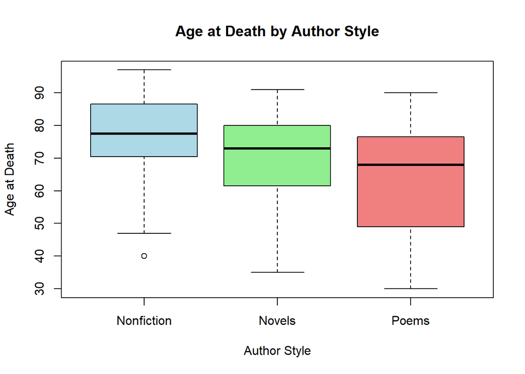

```r
boxplot(Age   ~ Type , data = womenpoet,
        main = "Age at Death by Author Style",
        xlab = "Author Style",
        ylab = "Age at Death",
        col = c("lightblue", "lightgreen", "lightcoral"))
```

Create a summary statistics table for age at death for each author type:

```r
summary_stats <- favstats(womenpoet$Age ~ womenpoet$Type, data = womenpoet)

# Display summary statistics
print(summary_stats)
```

```
  womenpoet$Type min    Q1 median    Q3 max     mean       sd  n missing
1     Nonfiction  40 71.75   77.5 86.25  97 76.87500 14.09691 24       0
2         Novels  35 61.50   73.0 80.00  91 71.44776 13.05151 67       0
3          Poems  30 49.50   68.0 75.75  90 63.18750 17.29710 32       0
```

List the mean and standard deviations of age at death for:

1. Novelists: **mean_age = 71.44776, sd_age = 13.05151**
2. Poets: **mean_age = 63.18750, sd_age = 17.29710**
3. Non-fiction: **mean_age = 76.87500, sd_age = 14.09691**

## Perform the Appropriate Analysis

State your null and alternative hypotheses:

$$H_o: \mu_1 = \mu_2 = ...\mu_k$$
$$H_a: \text{at least one } \mu_k \text{ is different}$$

Perform an Analysis of Variance test including checking for the appropriateness of our analysis.

```r
# extract only the standard deviations from favstats using th `$`:

sds <- favstats(womenpoet$Age ~ womenpoet$Type)$sd

# Compare the max/min to 2

max(sds) / min(sds)
```

```
[1] 1.325295
```

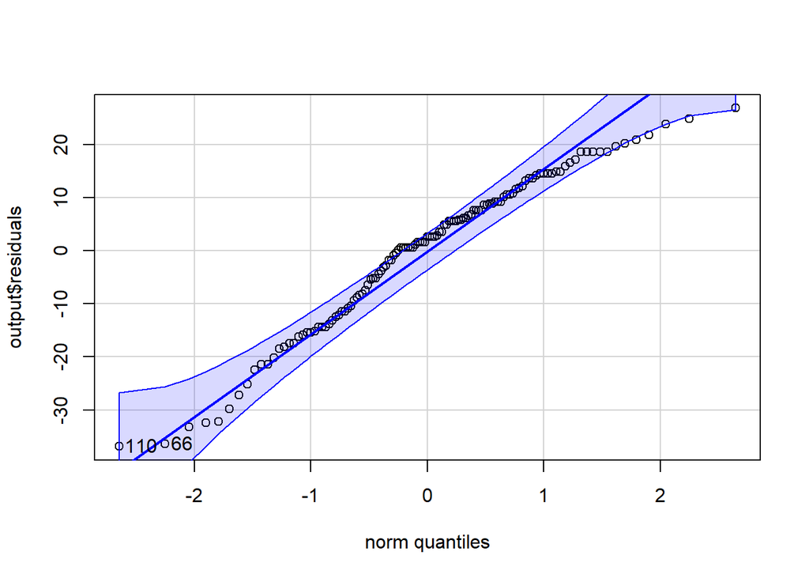

```
[1] 110  66
```

```r
# if max/min < 2, then we're ok

# Name the ANOVA output:
output <- aov(womenpoet$Age ~ womenpoet$Type)

qqPlot(output$residuals)
```

```r
# Summarise the ANOVA output to get test statistics, DF, P-value, etc:
summary(output)
```

```
                Df Sum Sq Mean Sq F value  Pr(>F)
womenpoet$Type   2   2744  1372.1   6.563 0.00197 **
Residuals      120  25088   209.1
---
Signif. codes:  0 '***' 0.001 '**' 0.01 '*' 0.05 '.' 0.1 ' ' 1
```

What is the test statistic?  
**6.563**

What are the degrees of freedom for your analysis? a. Numerator (between Groups) Degrees of Freedom  
**2** b. Denominator (within groups) Degrees of Freedom  
**120**

What is the P-value?  
**0.00197**

Do you reject the null hypothesis? Why?  
**We reject the null hypothesis because the P-value (0.00197) is less than the significance level. This indicates that there is a statistically significant difference in the average age at death among female poets, novelists, and non-fiction writers.**

State your conclusion in context of the problem.

Can we trust the p-value?  
**Yes**  
a. Check for equal standard deviation (is the ratio of the largest SD / smallest SD greater than 2?)  
**The ratio is less than 2.**  
b. Check Normality of the residuals (`qqPlot()`)  
**We can conclude that the standard deviations are approximately equal.**

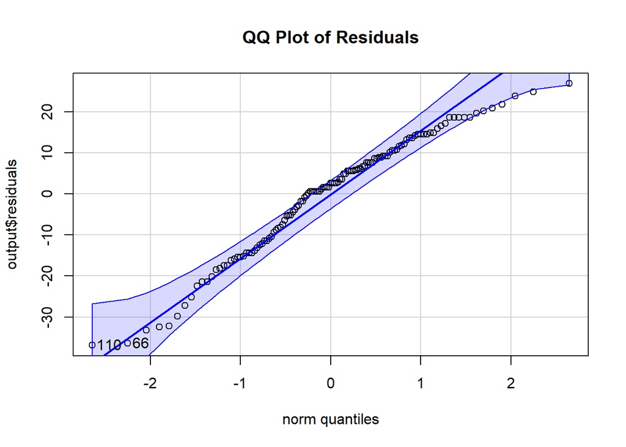

```
[1] 110  66
```

```r
qqPlot(output$residuals, main = "QQ Plot of Residuals")
```

# Testing Mosquitos

## Introduction

A study was conducted to determine if different types of material can reduce the amount of mosquito human contact. The researchers evaluated five different types of patches 1=Odomos, 2=Deltamethrin, 3=Cyfluthrin, 4=D+O, 5=C+O.

The amount of mosquito human contact was measured to assess any differences between the five different types of material. Use a level of significance of 0.05.

## Load the Data

```r
MosquitoPatch <- rio::import("https://raw.githubusercontent.com/rdcromar/Math221D/main/MosquitoPatch.csv") %>% mutate(Treatment = factor(Treatment))
```

## Review the Data

Create a side-by-side boxplot for human contact for each of the treatment groups.

Add a title and change the colors of the boxes.

```r
glimpse(MosquitoPatch)
```

```
Rows: 150
Columns: 2
$ Treatment <fct> 1, 1, 1, 1, 1, 1, 1, 1, 1, 1, 1, 1, 1, 1, 1, 1, 1, 1, 1, 1, …
$ mosqs     <dbl> 4.50, 10.04, 13.05, 0.26, 10.61, 10.89, 6.86, 6.97, 6.90, 5.…
```

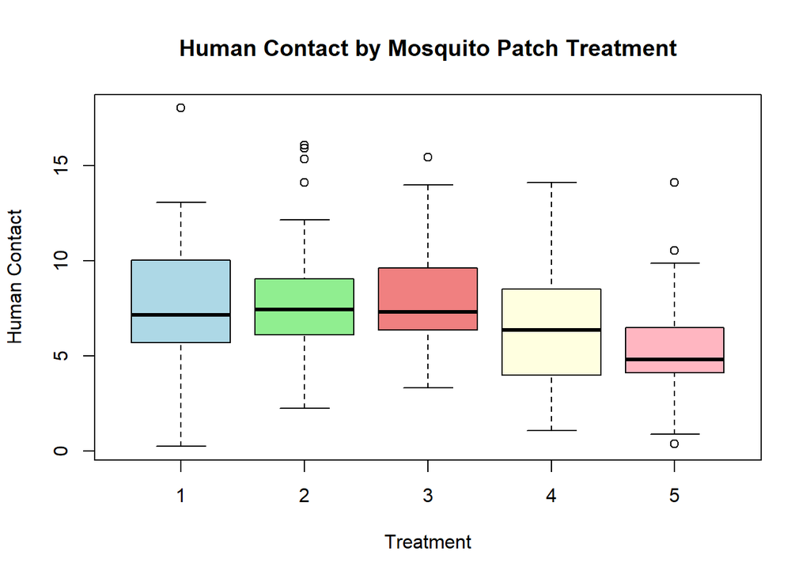

```r
boxplot(mosqs ~ Treatment, data = MosquitoPatch,
        main = "Human Contact by Mosquito Patch Treatment",
        xlab = "Treatment",
        ylab = "Human Contact",
        col = c("lightblue", "lightgreen", "lightcoral", "lightyellow", "lightpink"))
```

Create a summary statistics table for human contact for each of the treatment groups:

```r
summary_stats <- favstats(mosqs ~ Treatment, data = MosquitoPatch)
print(summary_stats)
```

```
  Treatment  min     Q1 median     Q3   max     mean       sd  n missing
1         1 0.26 5.7375  7.140 9.9075 18.01 7.900667 3.366488 30       0
2         2 2.26 6.1225  7.445 8.9050 16.07 8.133000 3.460182 30       0
3         3 3.33 6.3975  7.320 9.6225 15.44 8.032667 3.010318 30       0
4         4 1.10 4.0100  6.355 8.2500 14.10 6.333333 3.121368 30       0
5         5 0.39 4.1500  4.825 6.4725 14.10 5.367000 3.067773 30       0
```

What do you observe?  
**There appears to be some variance.**

What is the maximum standard deviation?  
**3.460182**

What is the minimum standard deviation?  
**3.010318**

## Perform the Appropriate Analysis

State your null and alternative hypotheses:

$$H_o: \mu_1 = \mu_2 = ...\mu_k$$
$$H_a: \text{at least one } \mu_k \text{ is different}$$

Perform an Analysis of Variance test including checking for the appropriateness of our analysis.

```r
# extract only the standard deviations from favstats using th `$`:

sds <- favstats(MosquitoPatch$mosqs ~ MosquitoPatch$Treatment)$sd

# Compare the max/min to 2

max(sds) / min(sds)
```

```
[1] 1.149441
```

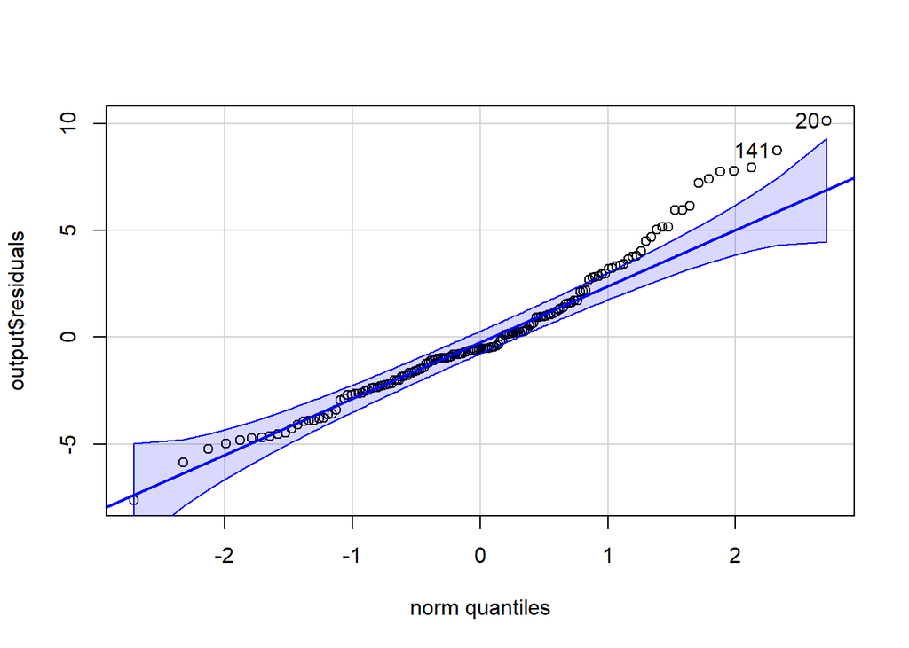

```
[1]  20 141
```

```r
# if max/min < 2, then we're ok

# Name the ANOVA output:
output <- aov(MosquitoPatch$mosqs ~ MosquitoPatch$Treatment)

qqPlot(output$residuals)
```

```r
# Summarise the ANOVA output to get test statistics, DF, P-value, etc:
summary(output)
```

```
                         Df Sum Sq Mean Sq F value  Pr(>F)
MosquitoPatch$Treatment   4  184.6   46.16    4.48 0.00192 **
Residuals               145 1494.1   10.30
---
Signif. codes:  0 '***' 0.001 '**' 0.01 '*' 0.05 '.' 0.1 ' ' 1
```

What is the test statistic (F-value)?  
**4.48**

What are the degrees of freedom for your analysis?

1. Numerator (between Groups) Degrees of Freedom  
   **4**
2. Denominator (within groups) Degrees of Freedom  
   **145**

What is the P-value?  
**0.00192**

Do you reject the null hypothesis? Why?  
**Since the P-value (0.00192) is less than the significance level, we reject the null hypothesis.There is a significant difference in the mean human contact among the five mosquito patch treatments. This suggests that at least one of the treatments is more effective or less effective in reducing mosquito human contact compared to the others.**

State your conclusion in context of the problem.

Can we trust the p-value?  
**Yes**  
a. Check for equal standard deviation (is the ratio of the largest SD / smallest SD greater than 2?)  
**The ratio is less than 2.**  
b. Check Normality of the residuals (`qqPlot()`)  
**We can conclude that the standard deviations are approximately equal.**

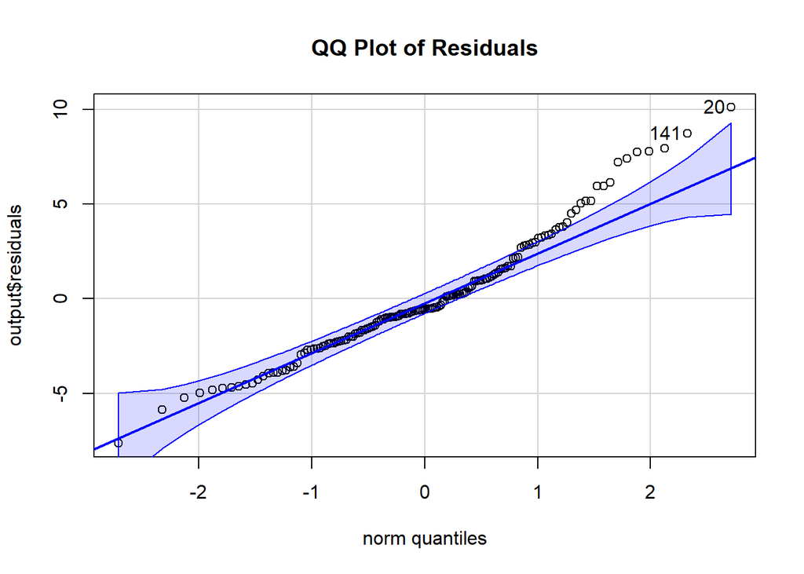

```
[1]  20 141
```

```r
qqPlot(output$residuals, main = "QQ Plot of Residuals")
```